# Adrien HANS & Tanguy JEANNEAU

## Exercice 1 : prise en main et comparaison à l’ACP

```python
import tensorflow as tf
x = tf.placeholder(tf.float32,shape=[])
y = tf.placeholder(tf.float32,shape=[])
f = x*x + 2*y
init = tf.global_variables_initializer()
some_x = [1,2,3]
some_y = [2,3,4]
with tf.Session() as sess:
    init.run()
    for i in range(len(some_x)):
        print(sess.run(f,feed_dict={x: some_x[i],y: some_y[i]}))
```

```
5.0
10.0
17.0
```

### Question 1 :

*En vous documentant sur `tf.gradients`, évaluez le gradient de f en les mêmes trois couples de points que dans le code précédent.*

```python
x = tf.placeholder(tf.float32,shape=[])
y = tf.placeholder(tf.float32,shape=[])
f = x*x + 2*y
init = tf.global_variables_initializer()
some_x = [1,2,3]
some_y = [2,3,4]
grad=tf.gradients(f, [x,y])

with tf.Session() as sess:
    init.run()
    for i in range(len(some_x)):
        print(sess.run(grad,feed_dict={x: some_x[i],y: some_y[i]}))
```

```
[2.0, 2.0]
[4.0, 2.0]
[6.0, 2.0]
```

**Nous avons évalué le gradient de f en les mêmes trois couples de points que dans le code précédent.**

**Puisque** $$f(x,y)=x^2+2y$$

**le gradient de f est :** \begin{pmatrix} 2x \\ 2 \end{pmatrix}

**Donc le résultat obtenu est le bon en ces points.**

### Question 2 :

*Récupérez la représentation intermédiaire générée par l’auto-encoder pour tout le dataset et affichez le résultat avec un plot 2D.*

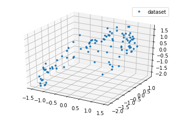

```python
import tensorflow as tf
# if the import fails, try to install tf : pip install --upgrade tensorflow
from sklearn.preprocessing import StandardScaler
import numpy.random as rnd
import numpy as np
import os
import sys
import matplotlib.pyplot as plt
from mpl_toolkits.mplot3d import Axes3D

# to work on the same dataset as students
def reset_graph(seed=42):
    tf.reset_default_graph()
    tf.set_random_seed(seed)
    np.random.seed(seed)

####################
#Dataset generation#
####################

rnd.seed(4)
m = 200
w1, w2 = 0.1, 0.3
noise = 0.1

angles = rnd.rand(m) * 3 * np.pi / 2 - 0.5
data = np.empty((m, 3))
data[:, 0] = np.cos(angles) + np.sin(angles)/2 + noise * rnd.randn(m) / 2
data[:, 1] = np.sin(angles) * 0.7 + noise * rnd.randn(m) / 2
data[:, 2] = data[:, 0] * w1 + data[:, 1] * w2 + noise * rnd.randn(m)

scaler = StandardScaler()
X_train = scaler.fit_transform(data[:100])
X_test = scaler.transform(data[100:])

fig = plt.figure()
ax = fig.gca(projection='3d')
ax.plot(X_train[:,0], X_train[:,1], X_train[:,2],'.', label='dataset')
ax.legend()
plt.savefig("dataset")
plt.show()

##########################
#PCA with an auto-encoder#
##########################

d_in = 3 #input dimensionality
d_hid = 2 #code dimensionality
d_out = d_in #output dimensionality

learning_rate = 0.01

initializer = tf.contrib.layers.variance_scaling_initializer()
activation = tf.nn.elu

#Input data
X = tf.placeholder(tf.float32,shape=[None, d_in])

#Hidden layer (code generating layer)
weights1_init = initializer([d_in, d_hid])
weights1 = tf.Variable(weights1_init,dtype=tf.float32,name="weights1")
biases1 = tf.Variable(tf.zeros(d_hid),name="biases1")
hidden = activation(tf.matmul(X,weights1) + biases1)

#Output layer (input reconstruction)
weights2 = tf.transpose(weights1,name="weights2")
biases2 = tf.Variable(tf.zeros(d_out),name="biases2")
outputs = activation(tf.matmul(hidden,weights2) + biases2)

#Objective function: MSE
J = tf.reduce_mean(tf.square(outputs - X))

optimizer = tf.train.AdamOptimizer(learning_rate)
training_op = optimizer.minimize(J)

init = tf.global_variables_initializer()

n_iterations = 1000

errors=[]
with tf.Session() as sess:
    init.run()
    for iteration in range(n_iterations):
        training_op.run(feed_dict={X: X_train})
        errors.append(J.eval(feed_dict={X:X_train}))
    results_2D=sess.run(hidden,feed_dict={X: scaler.transform(data)})
```

**Nous avons récupéré la représentation intermidiaire générée par l'auto-encoder pour tout le dataset grâce à la ligne `results_2D=sess.run(hidden,feed_dict={X: scaler.transform(data)})`**

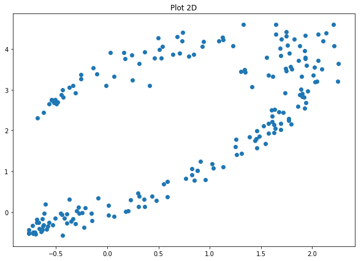

```python
fig=plt.figure(figsize=(10,7))
plt.title('Plot 2D')
plt.scatter(results_2D[:,0], results_2D[:,1])
plt.show()
```

**On a affiché le résultat dans un plot 2D, on retrouve la même forme 'applatie' quand dans la représentation précèdente.**

### Question 3 :

*Quelle fonction d’activation est utilisée ? Documentez vous sur ses spécificités.*

**La fonction d'activation utilisée est `tf.nn.elu` :**

$$elu(x)= \begin{cases} e^x -1 & \quad \text{if } \text{ x<0}\\ x & \quad \text{otherwise} \end{cases}$$

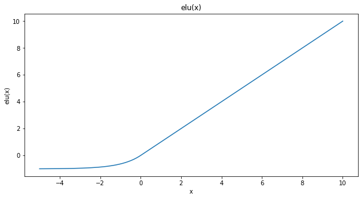

```python
def elu(x):
    if x<0:
        return np.exp(x)-1
    else:
        return x

X=np.linspace(-5, 10, 1000)
vfunc = np.vectorize(elu)

fig=plt.figure(figsize=(10,5))
plt.xlabel('x')
plt.ylabel('elu(x)')
plt.title('elu(x)')
plt.plot(X, vfunc(X))
plt.show()
```

### Question 4 :

*Tracez l’évolution de l’erreur quadratique moyenne au fil des itérations.*

**On affiche l'erreur quadratique au fil des itérations :**

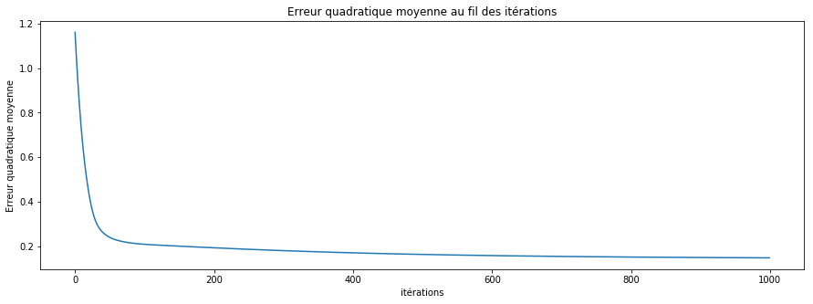

```python
fig=plt.figure(figsize=(15,5))
plt.title('Erreur quadratique moyenne au fil des itérations')
plt.xlabel('itérations')
plt.ylabel('Erreur quadratique moyenne')
plt.plot(range(n_iterations), errors)
plt.show()
```

**Comme attendu, l'erreur quadratique décroit au fil des itérations.**

### Question 5:

*Expliquez pourquoi d’un point de vue théorique, cette méthode n’est pas formellement équivalente à une ACP.*

**La différence avec une ACP est qu'ici une transformation non-linéraire est utilisée alors que ce n'est pas le cas avec une ACP.**

## Exercice 2 : un auto-encoder multi-couches pour MNIST

### Question 1 :

*Le code du fichier autoenc2_etu.py génère une erreur quand vous l’exécutez au départ. Cela est du au fait que le graphe de calcul est incomplet. En effet, en vous inspirant du code de l’exercice précédent et de celui de la première couche, vous devez rajouter les couches 2, 3 ainsi que celle de sortie correspondant aux inputs reconstruites.*

```python
import tensorflow as tf
# if the import fails, try to install tf : pip install --upgrade tensorflow
import numpy as np
import os
import sys
import matplotlib.pyplot as plt

# to work on the same dataset as students
def reset_graph(seed=42):
    tf.reset_default_graph()
    tf.set_random_seed(seed)
    np.random.seed(seed)


################
#Dataset import#
################

from tensorflow.examples.tutorials.mnist import input_data
mnist = input_data.read_data_sets("/tmp/data/")

##########################
#PCA with an auto-encoder#
##########################

reset_graph()

d_inputs = 28 * 28
d_hidden1 = 300
d_hidden2 = 150  # codings
d_hidden3 = d_hidden1
d_outputs = d_inputs

learning_rate = 0.01
l2_reg = 0.0005

initializer = tf.contrib.layers.variance_scaling_initializer()
activation = tf.nn.elu
regularizer = tf.contrib.layers.l2_regularizer(l2_reg)

#Input data
X = tf.placeholder(tf.float32,shape=[None, d_inputs])

#Hidden layer1 (code generating layer)
weights1_init = initializer([d_inputs, d_hidden1])
weights1 = tf.Variable(weights1_init, dtype=tf.float32, name="weights1")
biases1 = tf.Variable(tf.zeros(d_hidden1), name="biases1")
hidden1 = activation(tf.matmul(X, weights1) + biases1)


#Hidden layer2 (code generating layer)
weights2_init = initializer([d_hidden1, d_hidden2])
weights2 = tf.Variable(weights2_init,dtype=tf.float32,name="weights2")
biases2 = tf.Variable(tf.zeros(d_hidden2),name="biases2")
hidden2 = activation(tf.matmul(hidden1,weights2) + biases2)


#Hidden layer3 (intermediate representation reconstruction layer)
weights3_init = initializer([d_hidden2, d_hidden3])
weights3 = tf.Variable(weights3_init,dtype=tf.float32,name="weights3")
biases3 = tf.Variable(tf.zeros(d_hidden3),name="biases3")
hidden3 = activation(tf.matmul(hidden2,weights3) + biases3)

#Output layer (input reconstruction)
weights4_init = initializer([d_hidden3, d_outputs])
weights4 = tf.Variable(weights4_init,dtype=tf.float32,name="weights4")
biases4 = tf.Variable(tf.zeros(d_outputs),name="biases4")
outputs = activation(tf.matmul(hidden3,weights4) + biases4)



#Objective function: MSE + L2 penalty
reconstruction_loss = tf.reduce_mean(tf.square(outputs - X))
reg_loss = regularizer(weights1) + regularizer(weights2) +regularizer(weights3) + regularizer(weights4)
J = reconstruction_loss + reg_loss

optimizer = tf.train.AdamOptimizer(learning_rate)
training_op = optimizer.minimize(J)

init = tf.global_variables_initializer()

n_epochs = 5
batch_size = 150

with tf.Session() as sess:
    X_test =  mnist.test.next_batch(batch_size)[0]
    init.run()
    for epoch in range(n_epochs):
        n_batches = mnist.train.num_examples // batch_size
        for iteration in range(n_batches):
            print("\r{}%".format(100 * iteration // n_batches), end="")
            sys.stdout.flush()
            X_batch, y_batch = mnist.train.next_batch(batch_size)
            sess.run(training_op, feed_dict={X: X_batch})
        print("Erreur quadratique moyenne de {err:.3f} pour {nb} epochs".format(err=J.eval(feed_dict={X:X_test}), nb=epoch+1))
    sorties=outputs.eval(feed_dict={X:X_test})
```

```
Extracting /tmp/data/train-images-idx3-ubyte.gz
Extracting /tmp/data/train-labels-idx1-ubyte.gz
Extracting /tmp/data/t10k-images-idx3-ubyte.gz
Extracting /tmp/data/t10k-labels-idx1-ubyte.gz
99%Erreur quadratique moyenne de 0.065 pour 1 epochs
99%Erreur quadratique moyenne de 0.045 pour 2 epochs
99%Erreur quadratique moyenne de 0.043 pour 3 epochs
99%Erreur quadratique moyenne de 0.044 pour 4 epochs
99%Erreur quadratique moyenne de 0.044 pour 5 epochs
```

**En s'inspirant du code précédent, nous avons bien ajouté les couches 2 et 3 ainsi que celle de sortie correspondant aux inputs reconstruites.**

**Le code s'execute sans erreur.**

### Question 2 :

*Affichez à l’aide d’un print l’erreur quadratique moyenne au fil des epoch*

**Nous avons affiché l'erreur quadratique moyenne au fil des epochs dans le code de la question précédente, grâce aux deux dernières lignes.**

### Question 3 :

*Obtenez les images reconstruites pour tout le test set et affichez un couple d’image avant/après reconstruction.*

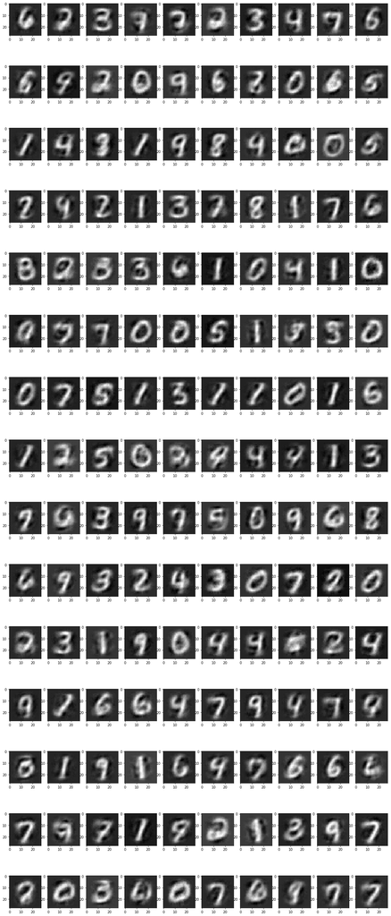

```python
fig=plt.figure(figsize=(20,50))
n=sorties.shape[0]
for i in range(sorties.shape[0]):
    plt.subplot(n//10, 10, i+1)
    plt.imshow(sorties[i].reshape(28,28), cmap='gray')
plt.show()
```

**Couple d'images avant/après reconstruction :**

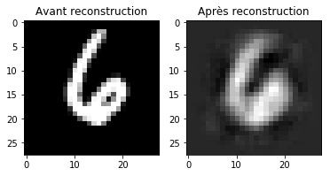

```python
plt.subplot(121)
plt.title('Avant reconstruction')
plt.imshow(X_test[0].reshape(28,28), cmap='gray')
plt.subplot(122)
plt.title('Après reconstruction')
plt.imshow(sorties[0].reshape(28,28), cmap='gray')
plt.show()
```

## Exercice 3 : stacked auto-encoder et pre-training pour MNIST

### Question 1 :

*Mettez en place le graphe correspondant*

**Nous avons mis en place le graphe correspondant.**

### Question 2 :

*Générez les représentations intermédiaires z(i,1) à l’aide la couche apprise pour tout le train set.*

**Nous avons inséré la ligne de code suivante dans la session après la boucle d'apprentissage de la phase 1, nécessaire à la réalisation de cette opération :**

```
X_train = mnist.train.next_batch(mnist.train.num_examples)[0]
Z_train = sess.run(hidden1, feed_dict={X:X_train})
```

### Question 3 :

*Phase 2*

**Nous avons complété les parties de codes correspondantes.**

### Question 4 :

*Décommentez, la partie du code correspondant à la phase 2 dans la session. Il y a une seule ligne de code à compléter. Vous devez prélever un mini-batch dans Z_train.*

**Nous avons complété la partie de code correspondante grâce à la ligne :**

`Z_batch = Z_train[iteration*batch_size:(iteration+1)*batch_size]`

### Question 5 :

*Sans relancer d’apprentissage, obtenez les images reconstruites pour tout le test set et vériﬁez qu’on obtient un résultat équivalent à l’exercice précédent.*

**Affichage:**

*Pour plus de lisibilité et surtout pour respecter l'ordre des questions, nous lançons d'abord le code entier à la question 6 puis nous affichons les images reconstruites dans un second temps dans cette question.*

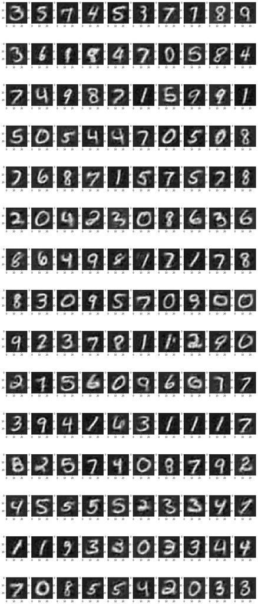

```python
fig=plt.figure(figsize=(20,50))
n=X_reconstruit.shape[0]
for i in range(X_reconstruit.shape[0]):
    plt.subplot(n//10, 10, i+1)
    plt.imshow(X_reconstruit[i].reshape(28,28), cmap='gray')
plt.show()
```

**Les images reconstruites ainsi obtenues sont en effet similaires à celles obtenues lors de l'exercice précédent.**

### Question 6 :

**On relance tout le programme ici pour plus de lisibilité:**

```python
#!/usr/bin/env python3
# -*- coding: utf-8 -*-
"""
Created on Wed Feb  7 14:46:02 2018

@author: johnklein
"""
import tensorflow as tf
# if the import fails, try to install tf : pip install --upgrade tensorflow
import numpy as np
import os
import sys
import matplotlib.pyplot as plt

# to work on the same dataset as students
def reset_graph(seed=42):
    tf.reset_default_graph()
    tf.set_random_seed(seed)
    np.random.seed(seed)


################
#Dataset import#
################

from tensorflow.examples.tutorials.mnist import input_data
mnist = input_data.read_data_sets("/tmp/data/")

##########################
#PCA with an auto-encoder#
##########################

reset_graph()

d_inputs = 28 * 28
d_hidden1 = 300
d_hidden2 = 150  # codings
d_hidden3 = d_hidden1
d_outputs = d_inputs
n_class = 10

learning_rate = 0.01
l2_reg = 0.0005

initializer = tf.contrib.layers.variance_scaling_initializer()
activation = tf.nn.elu
regularizer = tf.contrib.layers.l2_regularizer(l2_reg)

#Phase 1 (building its own tf subgraph)

#Input data
X = tf.placeholder(tf.float32,shape=[None, d_inputs])

#Hidden layer1 (first code generating layer)
#This is the missing code for the first hidden layer :
weights1_init = initializer([d_inputs, d_hidden1])
weights1 = tf.Variable(weights1_init, dtype=tf.float32, name="weights1")
biases1 = tf.Variable(tf.zeros(d_hidden1), name="biases1")
hidden1 = activation(tf.matmul(X, weights1) + biases1)

#Output layer (input reconstruction)
#This is the missing code for th eoutput layer :
weights_out = tf.transpose(weights1,name="weights_out")
biases_out = tf.Variable(tf.zeros(d_outputs),name="biases_out")
outputs = activation(tf.matmul(hidden1,weights_out) + biases_out)

#Objective function: MSE + L2 penalty
#We also complete the missing code for the objective function :
reconstruction_loss_phase1 = tf.reduce_mean(tf.square(outputs - X))
reg_loss_phase1 = regularizer(weights1)
J_phase1 = reconstruction_loss_phase1 + reg_loss_phase1

optimizer_phase1 = tf.train.AdamOptimizer(learning_rate)
training_op_phase1 = optimizer_phase1.minimize(J_phase1)

#Phase 2 (also building its own tf subgraph)

#Input data (intermediate representation)
Z = tf.placeholder(tf.float32,shape=[None, d_hidden1])

#Hidden layer2 (second code generating layer)
#We complete by the code below :
weights2_init = initializer([d_hidden1, d_hidden2])
weights2 = tf.Variable(weights2_init,dtype=tf.float32,name="weights2")
biases2 = tf.Variable(tf.zeros(d_hidden2),name="biases2")
hidden2 = activation(tf.matmul(Z,weights2) + biases2)


#Hidden layer3 (second intermediate representation reconstruction layer = output for this graph)
#We complete by the code below :
weights3_init = initializer([d_hidden2, d_hidden3])
weights3 = tf.Variable(weights3_init,dtype=tf.float32,name="weights3")
biases3 = tf.Variable(tf.zeros(d_hidden3),name="biases3")
hidden3 = activation(tf.matmul(hidden2,weights3) + biases3)

#Objective function: MSE + L2 penalty
reconstruction_loss_phase2 = tf.reduce_mean(tf.square(hidden3 - Z)) #MISSING CODE
reg_loss_phase2 = regularizer(weights2)
J_phase2 = reconstruction_loss_phase2 + reg_loss_phase2

optimizer_phase2 = tf.train.AdamOptimizer(learning_rate)
training_op_phase2 = optimizer_phase2.minimize(J_phase2)


##################################################################
#Stacking the layers together to build the multilayer autoencoder#
##################################################################

#Reconnecting first coding layer with the second one
layer2 = activation(tf.matmul(hidden1,weights2) + biases2) #MISSING CODE
layer3 = activation(tf.matmul(layer2,weights3) + biases3) #MISSING CODE
#Reconnecting first decoding layer with the output one
final_outputs = activation(tf.matmul(layer3,weights_out) + biases_out) #MISSING CODE



####################################################
#Stacking the layers together to build a classifier#
####################################################

#Adding a final layer (softmax) for supervised training on top of coding layers
weights3_init_stack = initializer([d_hidden2, n_class])
weights3_stack = tf.Variable(weights3_init_stack, dtype=tf.float32, name="weights3_mlp")
biases3_stack = tf.Variable(tf.zeros(n_class), name="biases3_mlp")
#We complete the missing code here :
logits = tf.matmul(layer2 , weights3_stack) + biases3_stack #MISSING CODE
y = tf.placeholder(tf.int32, shape=[None])
cross_entropy = tf.nn.sparse_softmax_cross_entropy_with_logits(labels=y, logits=logits)
reg_loss = regularizer(weights1) + regularizer(weights2) + regularizer(weights3_stack)
loss = cross_entropy + reg_loss
optimizer = tf.train.AdamOptimizer(learning_rate)
training_op = optimizer.minimize(loss)

correct = tf.nn.in_top_k(logits, y, 1)
accuracy = tf.reduce_mean(tf.cast(correct, tf.float32))



batch_size = 150
n_labeled_instances = 20000
init = tf.global_variables_initializer()
saver = tf.train.Saver() #one saver for all sessions

with tf.Session() as sess:
    n_epochs = 5
    init.run()
    #Phase 1
    for epoch in range(n_epochs):
        n_batches = mnist.train.num_examples // batch_size
        for iteration in range(n_batches):
            print("\r{}%".format(100 * iteration // n_batches), end="")
            sys.stdout.flush()
            X_batch, y_batch = mnist.train.next_batch(batch_size)
            sess.run(training_op_phase1, feed_dict={X: X_batch})


        #We complete here the missing code :
        X_train = mnist.train.next_batch(mnist.train.num_examples)[0]
        Z_train = sess.run(hidden1, feed_dict={X:X_train})


        #Phase 2
    for epoch in range(n_epochs):
        n_batches = mnist.train.num_examples // batch_size
        for iteration in range(n_batches):
            print("\r{}%".format(100 * iteration // n_batches), end="")
            sys.stdout.flush()
            #We complete the missing code :
            Z_batch = Z_train[iteration*batch_size:(iteration+1)*batch_size]
            sess.run(training_op_phase2, feed_dict={Z: Z_batch})
        #Ligne de code pour la question 5 :
        X_reconstruit = sess.run(final_outputs, feed_dict={X: X_batch})

    #Supervised learning
    n_epochs = 20
    print(weights1.eval())
    for epoch in range(n_epochs):
        n_batches = n_labeled_instances // batch_size
        for iteration in range(n_batches):
            print("\r{}%".format(100 * iteration // n_batches), end="")
            sys.stdout.flush()
            indices = np.random.permutation(n_labeled_instances)[:batch_size]
            X_batch, y_batch = mnist.train.images[indices], mnist.train.labels[indices]
            sess.run(training_op, feed_dict={X: X_batch, y: y_batch})
        accuracy_val = accuracy.eval(feed_dict={X: X_batch, y: y_batch})
        print("\r{}".format(epoch), "Train accuracy:", accuracy_val, end=" ")
        saver.save(sess, "./my_model_supervised.ckpt")
        accuracy_val = accuracy.eval(feed_dict={X: mnist.test.images, y: mnist.test.labels})
        print("Test accuracy:", accuracy_val)
```

```
Extracting /tmp/data/train-images-idx3-ubyte.gz
Extracting /tmp/data/train-labels-idx1-ubyte.gz
Extracting /tmp/data/t10k-images-idx3-ubyte.gz
Extracting /tmp/data/t10k-labels-idx1-ubyte.gz
99%[[ 6.07269833e-31 -6.60831327e-31 -7.30403665e-31 ... -2.14555907e-31
   1.52114846e-31  2.62677966e-31]
 [ 1.66085869e-07  7.98631788e-07 -1.02454169e-06 ...  8.37892742e-07
  -2.25421132e-07  1.01574676e-06]
 [-9.36349723e-33  1.23576984e-33  5.59364864e-34 ... -4.05074876e-33
   1.13893115e-33 -9.78152286e-33]
 ...
 [-1.07009370e-30 -6.89676935e-32 -3.23019265e-31 ...  2.86985285e-31
  -1.37608024e-31 -4.28076674e-31]
 [-1.21347029e-27  1.89587557e-28 -7.47867486e-29 ...  6.06674553e-29
   3.17454090e-28 -1.57974933e-28]
 [ 3.56575747e-09 -2.45724170e-08  7.13654202e-08 ... -9.44982759e-09
   1.74211987e-08 -8.77874626e-08]]
09% Train accuracy: 0.93333334 Test accuracy: 0.9215
19% Train accuracy: 0.94666666 Test accuracy: 0.9244
29% Train accuracy: 0.98 Test accuracy: 0.9442
3 Train accuracy: 0.9866667 Test accuracy: 0.9471
49% Train accuracy: 0.97333336 Test accuracy: 0.9457
59% Train accuracy: 0.96666664 Test accuracy: 0.9437
69% Train accuracy: 0.96666664 Test accuracy: 0.9514
79% Train accuracy: 0.98 Test accuracy: 0.9511
89% Train accuracy: 0.97333336 Test accuracy: 0.9384
99% Train accuracy: 0.9866667 Test accuracy: 0.9451
10% Train accuracy: 0.99333334 Test accuracy: 0.9529
11 Train accuracy: 0.96666664 Test accuracy: 0.937
12% Train accuracy: 0.98 Test accuracy: 0.9432
13% Train accuracy: 0.96666664 Test accuracy: 0.9589
14 Train accuracy: 0.98 Test accuracy: 0.9538
15 Train accuracy: 0.99333334 Test accuracy: 0.9469
16 Train accuracy: 0.97333336 Test accuracy: 0.9537
17 Train accuracy: 0.9866667 Test accuracy: 0.9547
18% Train accuracy: 0.9866667 Test accuracy: 0.961
19% Train accuracy: 0.99333334 Test accuracy: 0.9564
```

**On observe en effet que le classifieur fonctionne comme prévu !**

**Test accuracy de 96% environ pour les dernières epochs, et de quasiment 100% sur le train set.**

**Les résultats obtenus sont donc ceux attendus.**